# Visualizing Tissot’s Indicatrices in ggplot2

Alan Ward

2024-01-06

## Map projections

Projecting the surface of a three dimensional object onto a two dimensional surface is a significant mathematical challenge. The process of projection may distort the area or shape (and angle) of a spatial feature in addition to the distance between collections of spatial features. Here I demonstrate how to visualize the impacts various projections have on area, shape and distance.

Fortunately, R packages such as `sf` offer us this functionality behind the scenes through utilizing `PROJ`. `PROJ` is a library that enable us to quickly and conveniently switch between a large number of different projections.

```r
#Loading libraries
library(ggplot2)   # For generating the map visuals.
library(sf)        # For handling spatial objects, transformations etc.
library(dplyr)     # Data manipultaion and wrangling
library(rworldmap) # Data source for world map
```

First we need to import the map of the world

```r
world<- getMap()%>%            #Importing map file
  st_as_sf()%>%                #Converting it into an 'sf' object
  st_transform(., crs = 4326)  #Transforming the coordinate reference                                      system.
```

# Tissot’s Indicatrices

Now we must set up our grid of Tissot’s indicatices. These are a grid of circles of equal size that are evenly spaced across longitude and latitude. They help us visualize and appreciate the distortion in shapes, areas, and distances that can occur through projection. This visualization technique was first presentd by the French mathematician Nicolas Auguste Tissot during the late 19th century.

```r
lon <- seq(-135,135, 45) # Defining the longitiudes (vertical grid lines)
lat <- seq(-70,70,35)    # Defining the latitudes (horizontal grid lines)

#Generating coordinates for each time combindation of lat and long
latlon<- lapply(lat, data.frame, lon)%>%
  bind_rows()
names(latlon) <- c("lat", "lon")

#Generating the circles to be used for our Tissot's indicatrices
tissots <-latlon%>%
  st_as_sf(., coords = c("lon", "lat"))%>% #Converting our latlon into `sf`
  st_set_crs(4326)%>%                      #Giving them a coordinate reference system
  st_buffer(., dist = units::set_units(500, "km")) #Generating circleswith a 500km radius from our points.

head(tissots)
```

```
## Simple feature collection with 6 features and 0 fields
## Geometry type: POLYGON
## Dimension:     XY
## Bounding box:  xmin: -148.4014 ymin: -74.53223 xmax: 103.4179 ymax: -65.46998
## Geodetic CRS:  WGS 84
##                         geometry
## 1 POLYGON ((-148.2988 -70.441...
## 2 POLYGON ((-85.74652 -65.791...
## 3 POLYGON ((-47.35994 -65.573...
## 4 POLYGON ((-1.080087 -74.496...
## 5 POLYGON ((47.86902 -74.4485...
## 6 POLYGON ((80.50167 -67.0979...
```

Now we are ready to put the map and grid of circles together to visualise and explore the impacts projections have on area,shape and distance.

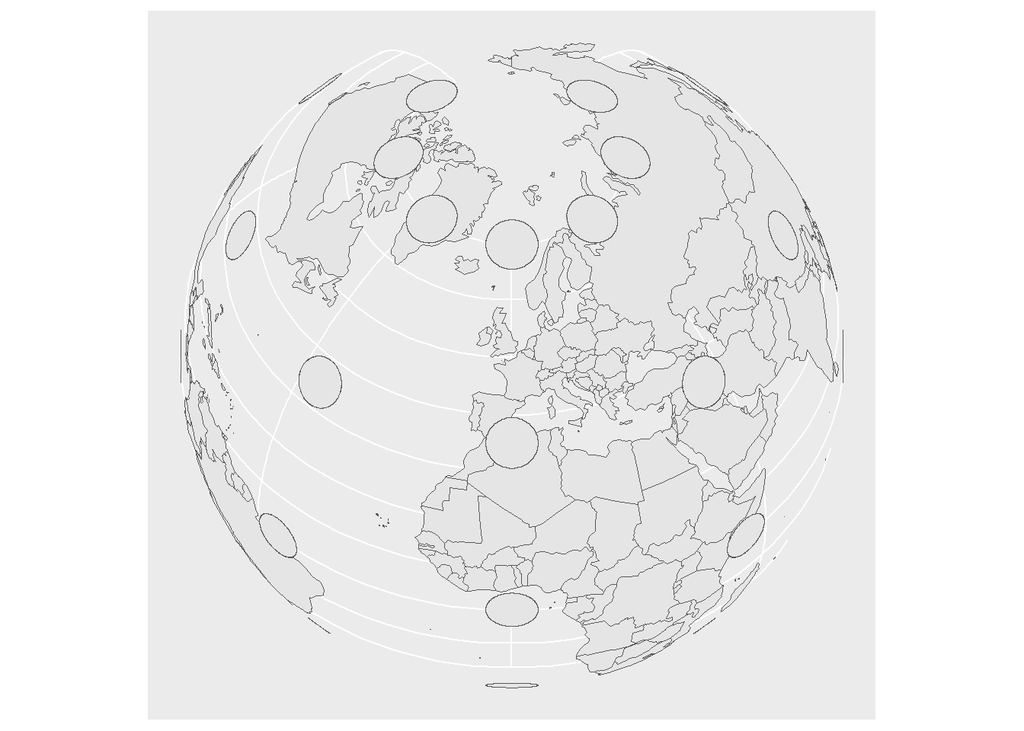

```r
ggplot()+
  geom_sf(data = world)+
  geom_sf(data = tissots)+
  coord_sf( crs= "+proj=ortho +lat_0=50 +lon_0 = 0")
```

#Mercator This is a commonly used map projection

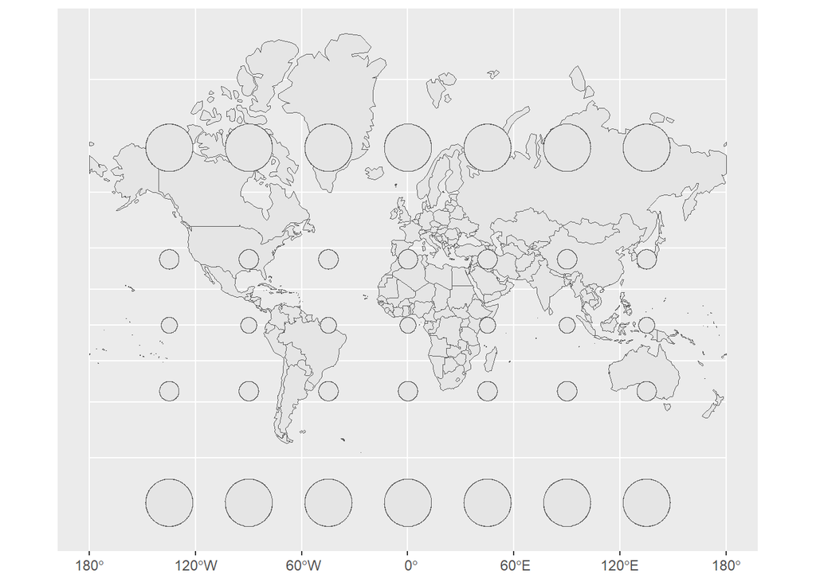

```r
ggplot()+
  geom_sf(data = world%>%
            filter(continent != "Antarctica"))+ #Antarctica too stretched
  geom_sf(data = tissots)+
  coord_sf(crs = "+proj=merc")
```

Notice that the shape has been preserved, but the areas of the landmasses has dramatically expanded at higher latitudes (further north and south) and shrunk at lower latitudes (closer to the equator).

# Interrupted Goode Homolosine

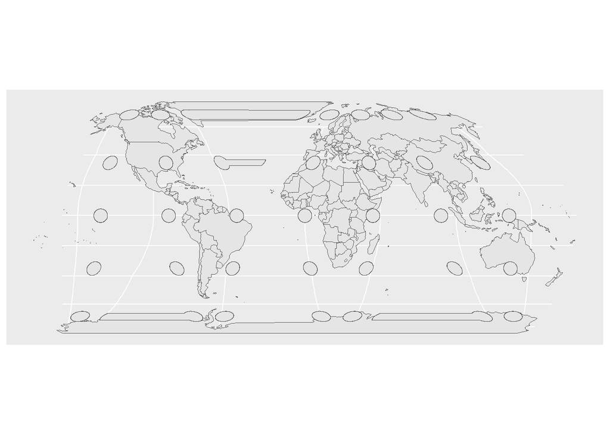

```r
ggplot()+
  geom_sf(data = world)+
  geom_sf(data = tissots)+
  coord_sf(crs = "+proj=igh")
```

# Azimuthal Equidistant

Area, size and distance are well preserved at 0 longitude but the distortion increases with increasing longitude.

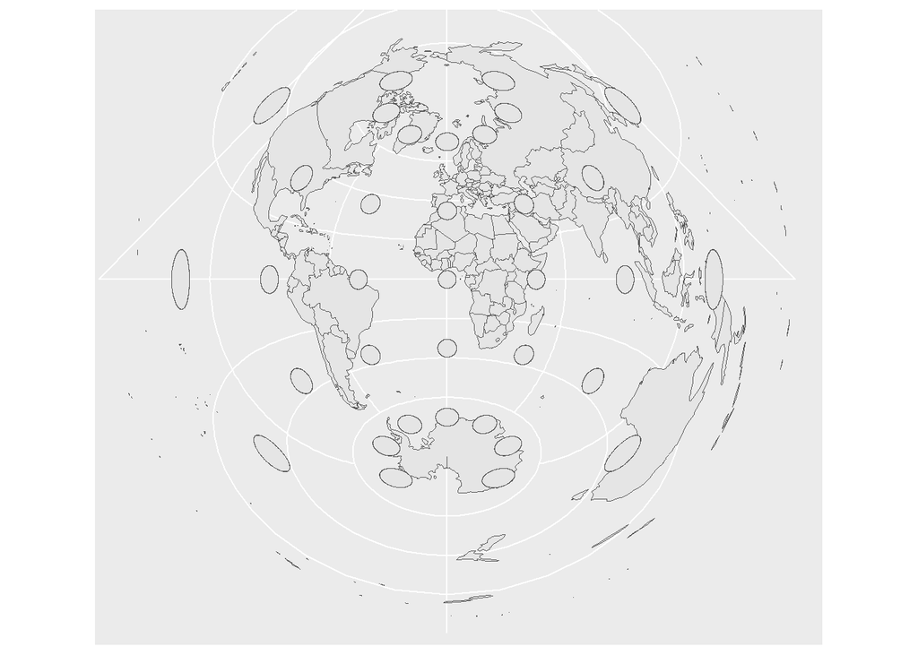

```r
ggplot()+
  geom_sf(data = world)+
  geom_sf(data = tissots)+
  coord_sf(crs = "+proj=aeqd")
```

# Nicolosi Globular

[figure not shown]

```r
ggplot()+
  geom_sf(data = world)+
  geom_sf(data = tissots)+
  coord_sf(crs = "+proj=nicol")
```

# van der Grinten IV

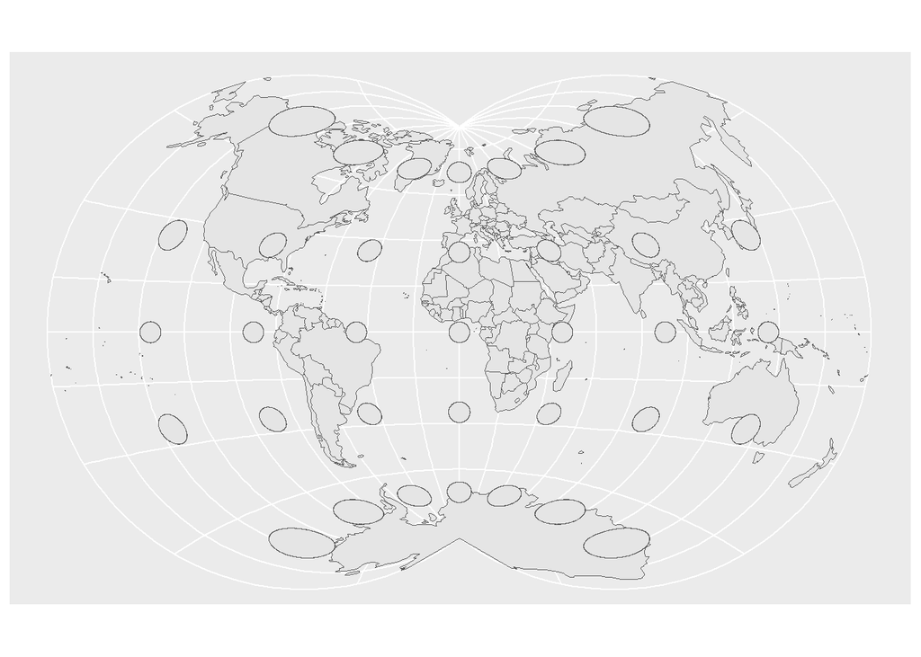

```r
ggplot()+
  geom_sf(data = world)+
  geom_sf(data = tissots)+
  coord_sf(crs = "+proj=vandg4")
```

Projections available can be viewed using the `sf_proj_info()` function available within the `sf` package.

I hope this has been useful to you.